# Publishing Notebooks

2023-11-21

## Jupyter Notebooks

Jupyter notebooks are very similar to Databricks notebooks. You can export a Databrick notebook to the jupyter notebook format. The file will have a .ipyn file extension.  
Jupyter can be installed on AVD. There is a version of rsconnect that can publish jupyter notebooks. There is also a plug in extension for jupyter notebooks that makes publishing very easy.

## Install requirements

Open a command prompt

[figure not shown]

Run the following command:

```
pip install notebook rsconnect_jupyter jupyter_contrib_nbextensions
```

## Setting path to Python scripts

Again in the command prompt:

```
echo %USERNAME%
```

This gives your username to replace in the following:

```
set NEWPATH=C:\Users\<USERNAME>\AppData\Roaming\Python\Python310\Scripts
set PATH=%PATH%;%NEWPATH%
```

## Set up Jupyter extensions

Still in the command prompt:

```
jupyter contrib nbextension install --user
jupyter nbextension enable varInspector/main
jupyter-nbextension install --py rsconnect_jupyter --user
jupyter-nbextension enable --py rsconnect_jupyter
jupyter-serverextension enable --py rsconnect_jupyter
jupyter notebook
```

The last command will open Jupyter in a browser.

## Opening/creating notebook

Jupyter will open at the root of the AVD drive.

[figure not shown]

Browse to where you saved your .ipyn file and open it. Or if testing, open a new notebook and ether add some code or copy this example into the first cell and run it. You can also rename the new notebook by clicking on the default “Untitled” name.

```
import matplotlib.pyplot as plt
import numpy as np

data = {'a': np.arange(50),
        'c': np.random.randint(0, 50, 50),
        'd': np.random.randn(50)}
data['b'] = data['a'] + 10 * np.random.randn(50)
data['d'] = np.abs(data['d']) * 100

plt.scatter('a', 'b', c='c', s='d', data=data)
plt.xlabel('entry a')
plt.ylabel('entry b')
plt.show()
```

[figure not shown]

## Delploying Notebook

Click on the button with the blue symbol to the right of the windows decorations and select “Publish to Posit Connect”.

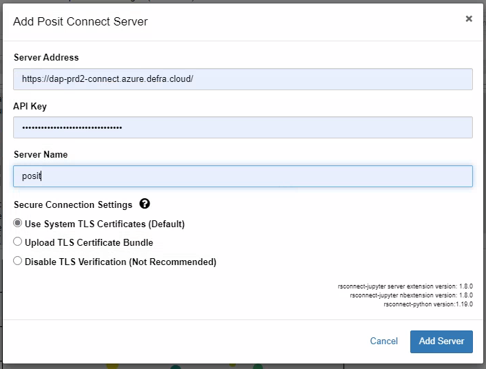

In the pop up window:

Server Address  
https://dap-prd2-connect.azure.defra.cloud/

API key

Add you own API key created in the Posit server as shown in the Publishing Python guide.

Server Name  
Add a nickname of your choice.

Click the “Add Server” button.

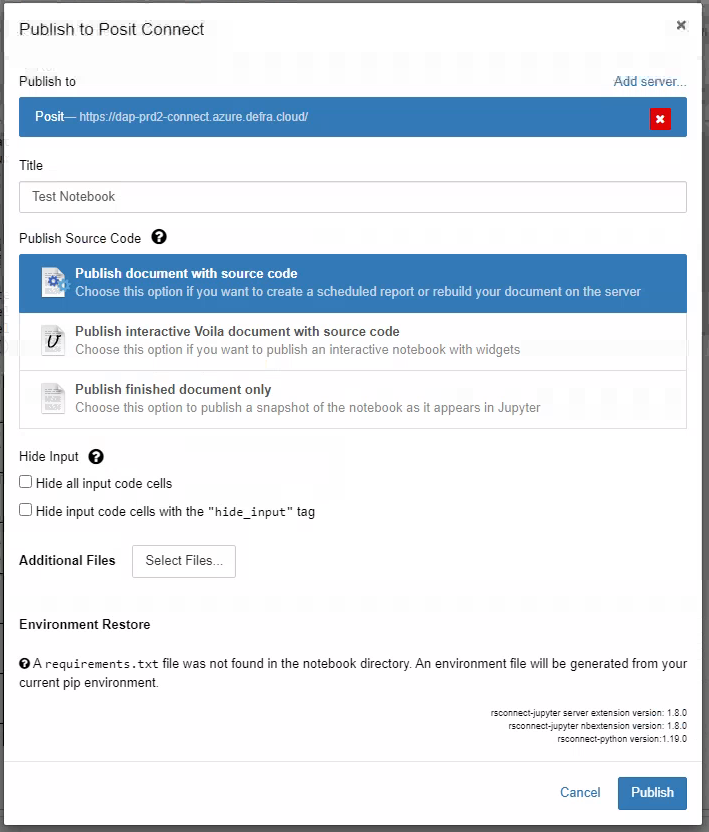

In the next pop up window you can edit the Tile if you wish and select the option that you prefer. Remember to add any additional files the notebook requires.

Click the “Publish” button.

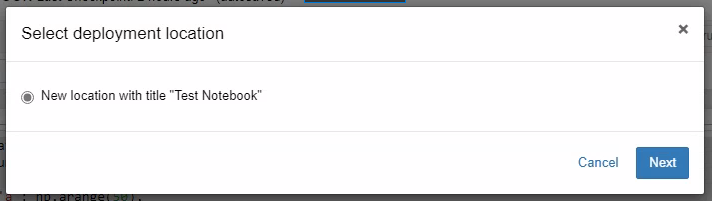

In the next pop up window select the radio button and click “Next”. This will return you to the previosu window, click “Publish” again. You will see some output at the bottom of the windows and it will disappear once complete.

## View notebook on the Posit server

No when you log into the Posit server and click on the COntent tab you will see you notebook listed. Click on it and select the access settings you require. See the Dashboard admin guide.

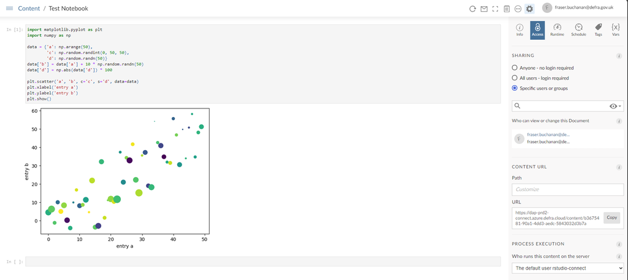